# HW_3_Osipov_AV

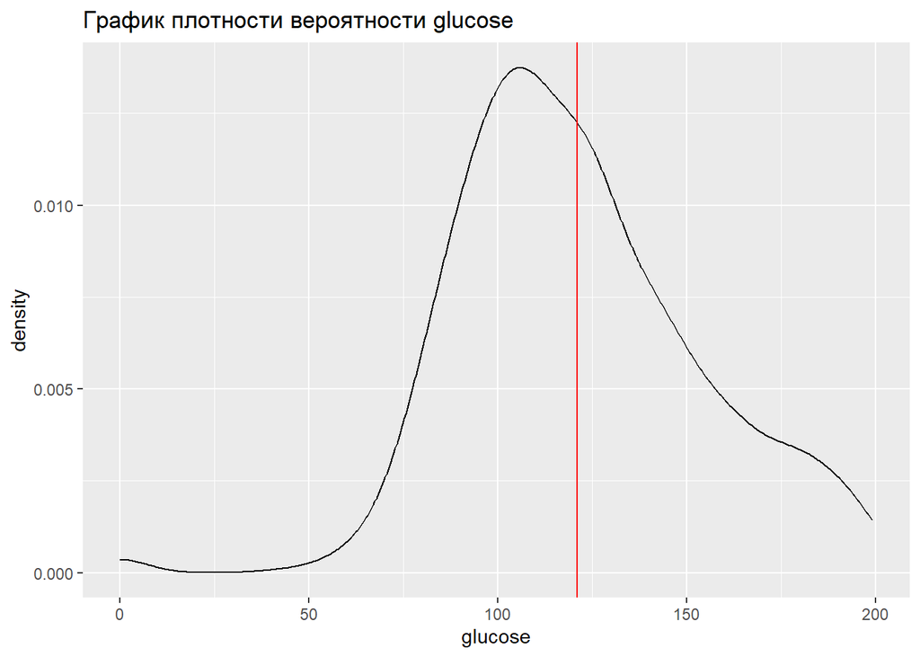

```r
dens <- ggplot(data = pima) +
  geom_density(aes(glucose)) +
  geom_vline(xintercept = mean(pima$glucose), color = 'red') +
  labs(title = "График плотности вероятности glucose")
print(dens)
```

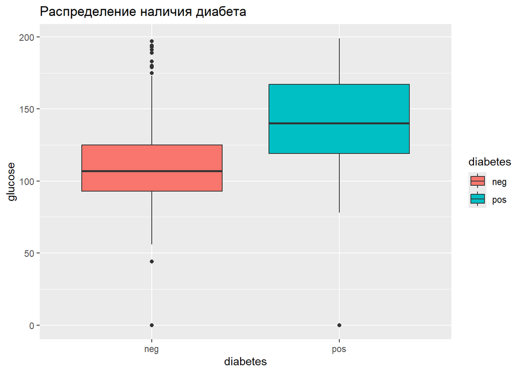

```r
box <- ggplot(data = pima) +
  geom_boxplot(aes(diabetes, glucose, fill = diabetes)) +
  labs(title = "Распределение наличия диабета")
print(box)
```

## 5. Постройте на одном графике две диаграммы рассеяния для наличия или отсутствия диабета. По оси X представьте значения обхвата трицепса, а по оси Y — массу тела. Выполните окрашивание, заливку и группирование по переменной diabetes.

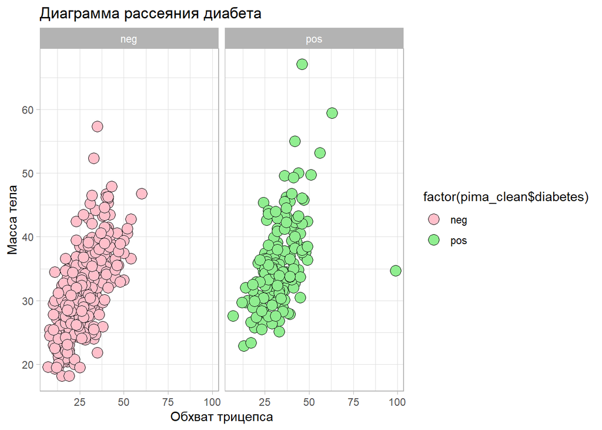

```r
# Удаление строк, где обхват трицепса или масса тела равны нулю
pima_clean <- subset(pima, triceps != 0 & mass != 0)
# Построение графика
facet <- ggplot(data = pima_clean,
                aes(x = triceps, y = mass)) +
  geom_point(color = "black", shape = 21, size = 4,
             aes(fill = factor(pima_clean$diabetes))) +
  scale_fill_manual(values = c("pink", "lightgreen")) +
  facet_grid(. ~ diabetes) +
  labs(title = "Диаграмма рассеяния диабета",
       x = "Обхват трицепса", y = "Масса тела") +
  theme_light()

print(facet)
```

##### Постройте на одном графике две диаграммы рассеяния для наличия или отсутствия диабета. По оси X представьте значения обхвата трицепса, а по оси Y — массу тела. Выполните окрашивание, заливку и группирование по переменной diabetes. — 3 балла

##### Загрузите файлы на GitHub, в форму приложите ссылку на него. Назовите RMarkdown-файл своими ФИО.

##### Что нужно отправить: ссылку на репозиторий, который будет содержать RMarkdown-файл с вашим решением.